# binary-3d

## 3次元二値画像解析

このチュートリアルでは3次元の画像解析を行ないます。基本的な考え方は2Dの二値画像解析と同じなので、まずそちらのチュートリアルを終わらせてからこちらにトライしてください。

ここでは50x50x50のサイズの画像を解析します。3次元画像の表現方法は色々ありますが、ここでは各層ごとの断面画像を用います。 つまり50x50の画像を50個用意します。 `data/` ディレクトリにファイルが置かれています。ファイル名は断面の順に付けておきます。

```python
ls data/
```

```
0000.png  0007.png  0014.png  0021.png  0028.png  0035.png  0042.png  0049.png
0001.png  0008.png  0015.png  0022.png  0029.png  0036.png  0043.png
0002.png  0009.png  0016.png  0023.png  0030.png  0037.png  0044.png
0003.png  0010.png  0017.png  0024.png  0031.png  0038.png  0045.png
0004.png  0011.png  0018.png  0025.png  0032.png  0039.png  0046.png
0005.png  0012.png  0019.png  0026.png  0033.png  0040.png  0047.png
0006.png  0013.png  0020.png  0027.png  0034.png  0041.png  0048.png
```

## データファイルの読み込み

まずはこの 50x50x50 の画像を読み込んで 50x50x50 の白黒配列を作ります。

```python
# 必要なライブラリの読み込み
import imageio
import numpy as np
import matplotlib.pyplot as plt
%matplotlib inline
```

3次元配列を作る前に 0000.png を読み込んでどんな画像か確認しましょう。

```python
image_0000 = imageio.v3.imread("data/0000.png")
```

```python
image_0000.shape, image_0000.dtype, np.max(image_0000), np.min(image_0000)
```

```
((50, 50), dtype('uint8'), 255, 0)
```

これは50x50の配列で、0 から255の値を持っています。つまりこの画像はグレイスケール画像のようです。中身を見てから実際に表示してみましょう。

```python
image_0000
```

```
array([[255, 255, 255, ..., 255, 255, 255],
       [255, 255, 255, ..., 255, 255, 255],
       [255, 255, 255, ..., 255, 255, 255],
       ...,
       [255, 255, 255, ...,   0,   0,   0],
       [255, 255, 255, ...,   0,   0,   0],
       [255, 255, 255, ...,   0,   0,   0]], dtype=uint8)
```

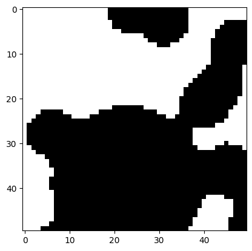

```python
plt.imshow(image_0000, "gray")
```

では50個の画像を読み込んで積み重ねます。

```python
pict = np.stack([
    imageio.v3.imread("data/{:04d}.png".format(n)) > 128
    for n in range(50)
], axis=0)
```

```python
pict.shape, pict.dtype
```

```
((50, 50, 50), dtype('bool'))
```

50x50x50の画像が完成しました。ではこれを3次元可視化しましょう。[pyvista](https://pyvista.org/)を使います． `opacity=0.7`として半透明にします．

```python
import pyvista as pv  # モジュールの読み込み
import homcloud.pyvistahelper as pvhelper  # HomCloud側のヘルパー関数を導入

pv.set_jupyter_backend('trame')  # Jupyter notebook のバックエンドを trame にする
```

```python
pl = pv.Plotter()
pl.add_mesh(pvhelper.Bitmap3D(pict).threshold(0.5), show_scalar_bar=False, opacity=0.7)
pl.show()
```

```
Widget(value="<iframe src='http://localhost:35959/index.html?ui=P_0x7f19c4472b60_0&reconnect=auto' style='widt…
```

## パーシステント図の計算

```python
import homcloud.interface as hc
```

```python
pdlist = hc.PDList.from_bitmap_levelset(hc.distance_transform(pict, signed=True), save_to="binary-3d.pdgm")
```

以下のようにしてファイルを読み込むこともできます。

```python
pdlist = hc.PDList("binary-3d.pdgm")
```

## パーシステント図の解析(1次)

1次のパーシステント図を調べていきましょう。

```python
pd1 = pdlist.dth_diagram(1)
```

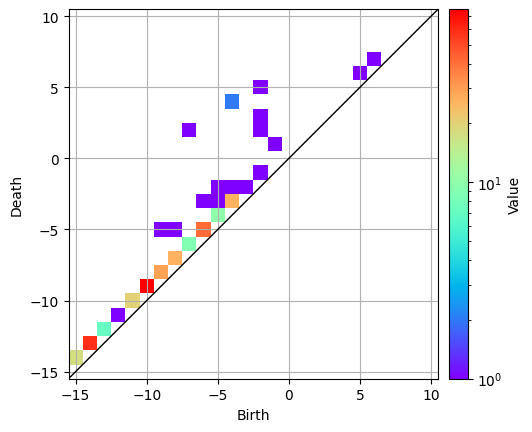

```python
pd1.histogram((-15.5, 10.5), 26).plot(colorbar={"type": "log"})
```

`(-4, 4)` の所に2つbirth-death pairがあるようです。これを確認しましょう

```python
pairs = pd1.pairs_in_rectangle(-4, -4, 4, 4)
pairs
```

```
[Pair(-4.0, 4.0), Pair(-4.0, 4.0)]
```

確かに2つあります。

### 逆解析(1次)

この2つのペアがどのような穴を表現しているのか見てみましょう。1次のパーシステントホモロジーを見ているわけですから、 何らかのリング構造を見ているはずです。それを計算しましょう。

ここでは optimal cycle というものを使います。ポイントクラウドの解析ではoptimal volumeやvolume-optimal cycleというものを用いましたが、 それと似たものです(ちょっと違います)。`Pair.optimal_1_cycle`で計算します。

```python
optimal_1_cycles = [pair.optimal_1_cycle() for pair in pairs]
```

まずはこれを可視化しましょう。元のボクセルデータを重ねあわせて表示します。

```python
pl = pv.Plotter()
pl.add_mesh(pvhelper.Bitmap3D(pict).threshold(0.5), show_scalar_bar=False, opacity=0.7)
for cycle in optimal_1_cycles:
    pl.add_mesh(cycle.to_pyvista_mesh(), color="red")
pl.show()
```

```
Widget(value="<iframe src='http://localhost:35959/index.html?ui=P_0x7f18d84f6110_1&reconnect=auto' style='widt…
```

次にこのリング構造がどういうパスを通っているのかを見ます。`Optimal1CycleForBitmap.path`を使います。通過点のピクセルの座標が得られます。

```python
optimal_1_cycles[0].path()
```

```
[(49, 4, 44),
 (49, 4, 43),
 (49, 4, 42),
 (49, 4, 41),
 (49, 4, 40),
 (49, 4, 39),
 (49, 4, 38),
 (48, 4, 38),
 (48, 4, 37),
 (48, 4, 36),
 (47, 4, 36),
 (47, 4, 35),
 (47, 4, 34),
 (46, 4, 34),
 (45, 4, 34),
 (44, 4, 34),
 (43, 4, 34),
 (43, 4, 33),
 (42, 4, 33),
 (41, 4, 33),
 (40, 4, 33),
 (39, 4, 33),
 (38, 4, 33),
 (37, 4, 33),
 (36, 4, 33),
 (36, 5, 33),
 (35, 5, 33),
 (34, 5, 33),
 (34, 6, 33),
 (34, 7, 33),
 (34, 8, 33),
 (34, 9, 33),
 (34, 10, 33),
 (34, 11, 33),
 (34, 11, 34),
 (34, 11, 35),
 (34, 11, 36),
 (34, 11, 37),
 (34, 11, 38),
 (34, 11, 39),
```

[output cut: 20 more lines]

```
 (44, 9, 48),
 (45, 9, 48),
 (45, 8, 48),
 (45, 8, 47),
 (46, 8, 47),
 (46, 7, 47),
 (46, 7, 46),
 (47, 7, 46),
 (47, 7, 45),
 (48, 7, 45),
 (48, 7, 44),
 (48, 6, 44),
 (48, 5, 44),
 (49, 5, 44),
 (49, 4, 44)]
```

```python
optimal_1_cycles[1].path()
```

```
[(16, 42, 45),
 (16, 41, 45),
 (16, 41, 46),
 (15, 41, 46),
 (15, 40, 46),
 (15, 40, 47),
 (14, 40, 47),
 (14, 39, 47),
 (14, 39, 48),
 (13, 39, 48),
 (13, 39, 49),
 (12, 39, 49),
 (11, 39, 49),
 (11, 38, 49),
 (11, 37, 49),
 (10, 37, 49),
 (10, 36, 49),
 (10, 35, 49),
 (10, 34, 49),
 (9, 34, 49),
 (9, 33, 49),
 (9, 32, 49),
 (8, 32, 49),
 (8, 31, 49),
 (8, 30, 49),
 (8, 29, 49),
 (8, 29, 48),
 (8, 29, 47),
 (8, 29, 46),
 (8, 29, 45),
 (8, 29, 44),
 (8, 29, 43),
 (8, 29, 42),
 (8, 29, 41),
 (9, 29, 41),
 (9, 29, 40),
 (9, 29, 39),
 (10, 29, 39),
 (10, 29, 38),
 (10, 29, 37),
```

[output cut: 20 more lines]

```
 (15, 41, 37),
 (15, 42, 37),
 (15, 42, 38),
 (16, 42, 38),
 (16, 42, 39),
 (16, 42, 40),
 (17, 42, 40),
 (18, 42, 40),
 (18, 42, 41),
 (18, 42, 42),
 (18, 42, 43),
 (18, 42, 44),
 (18, 42, 45),
 (17, 42, 45),
 (16, 42, 45)]
```

## パーシステント図の解析(0次)とその逆解析

次に0次のパーシステント図を解析していきましょう。

まず0次のパーシステント図をプロットします。

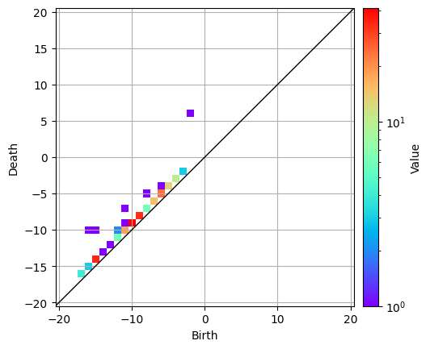

```python
pd0 = pdlist.dth_diagram(0)
pd0.histogram((-20.5, 20.5), 41).plot(colorbar={"type": "log"})
```

`(-16.0, -10.0), (-15.0, -10.0)` という2のbirth-death pairを詳しく調べていきましょう。 ボクセルデータの0次と2次の逆解析には`BitmapPHTrees` というクラスを使います(1次には使えないので、上で説明した `optimal_1_cycle` を代わりに使いました)。 `BitmapPHTrees.for_bitmap_levelset` は `PDList.from_bitmap_levelset` と似たインターフェースで逆解析用の情報を計算します。

この PHTrees という名前は、ここで計算されるものが木構造であることを意味しています。 n次元のビットマップデータに対して0次とn-1次の2つの情報を同時に計算して、2つの木構造を持っています。 この木構造を取りだすためには `PDList.bitmap_phtrees` というメソッドを使います。

```python
hc.BitmapPHTrees.for_bitmap_levelset(hc.distance_transform(pict, signed=True),
                                     save_to="binary-3d-tree.pdgm")
```

```
PDList(path=binary-3d-tree.pdgm)
```

以下のようにして計算したデータを読み込みます。

```python
pdlist_with_tree = hc.PDList("binary-3d-tree.pdgm")
```

0次の情報を取り出すのは `bitmap_phtrees(0)` を使います。

```python
phtree_0 = pdlist_with_tree.bitmap_phtrees(0)
```

`(-16.0, -10.0), (-15.0, -10.0)`という2つのbirth-death pairの情報を取り出すのには `pair_nodes_in_rectangle`を使いましょう。これは指定した範囲内にある birth-death pair (に対応する木構造のnode)をすべて取り出します。

```python
nodes_0 = phtree_0.pair_nodes_in_rectangle(-16, -15, -10, -10)
nodes_0
```

```
[BitmapPHTrees.Node(-15.0, -10.0), BitmapPHTrees.Node(-16.0, -10.0)]
```

取り出したデータは `BitmapPHTrees.Node` というクラスのインスタンスです。次にこれらの情報を可視化しましょう。

```python
pl = pv.Plotter()
pl.add_mesh(pvhelper.Bitmap3D(pict).threshold(0.5), show_scalar_bar=False, opacity=0.2)
pl.add_mesh(nodes_0[0].to_pyvista_mesh(), color="green")
pl.add_mesh(nodes_0[1].to_pyvista_mesh(), color="red", opacity=0.4)
pl.show()
```

```
Widget(value="<iframe src='http://localhost:35959/index.html?ui=P_0x7f18d84aee90_2&reconnect=auto' style='widt…
```

opacityを変えるなどして，可視化された情報をうまく観察してください。0次のPHなので、ボクセルの内側の領域に 対応しています。実はこの2つのbirth-death pairは木構造上の親子関係にあり、一方が他方の部分集合になっています。

緑の部分の形がどうも「ぎざぎざ」で不自然だな，というようにも見えるのは stable volume というのを代わりに使うと解決される可能性があります．次のように `stable_volume(1)` として「1ピクセル分縮める」と自然に見えることが多いです．

```python
pl = pv.Plotter()
pl.add_mesh(pvhelper.Bitmap3D(pict).threshold(0.5), show_scalar_bar=False, opacity=0.2)
pl.add_mesh(nodes_0[0].stable_volume(1).to_pyvista_mesh(), color="green")
pl.add_mesh(nodes_0[1].stable_volume(1).to_pyvista_mesh(), color="red", opacity=0.4)
pl.show()
```

```
Widget(value="<iframe src='http://localhost:35959/index.html?ui=P_0x7f18d84c81f0_3&reconnect=auto' style='widt…
```

それぞれの塊がより良い感じに見えていると思います．こうすると2つのbirth-death pairの対応する領域が分離されています．stable_volumeはノイズに強い部分を取り出す仕組みなので，これは「2つのbirth-death pairの親子関係はノイズで崩れやすい」ということを意味しています．

逆解析を使うときは，このように`stable_volume(1)`としておくことをお勧めしておきます．

## パーシステント図の解析(2次)とその逆解析

最後に2次のパーシステント図を解析していきましょう。

2次のパーシステント図をプロットします。

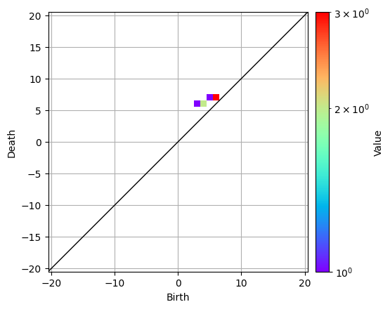

```python
pd2 = pdlist.dth_diagram(2)
pd2.histogram((-20.5, 20.5), 41).plot(colorbar={"type": "log"})
```

`(4, 6)`というbirth-death pairを調べます。逆解析には `bitmap_ph_trees(2)`を使います。2が次数です．

```python
phtree_2 = pdlist_with_tree.bitmap_phtrees(2)
```

(4, 6) という birth-death pairを調べましょう。まず `pair_nodes_in_rectangle` で (4, 6) という birth-death pair (に対応した tree の node) をすべて取り出します。

```python
nodes_2 = phtree_2.pair_nodes_in_rectangle(4, 4, 6, 6)
nodes_2
```

```
[BitmapPHTrees.Node(4.0, 6.0), BitmapPHTrees.Node(4.0, 6.0)]
```

```python
pl = pv.Plotter()
pl.add_mesh(pvhelper.Bitmap3D(pict).threshold(0.5), show_scalar_bar=False, opacity=0.2)
pl.add_mesh(nodes_2[0].to_pyvista_mesh())
pl.add_mesh(nodes_2[1].to_pyvista_mesh())
pl.show()
```

```
Widget(value="<iframe src='http://localhost:35959/index.html?ui=P_0x7f18d825afe0_4&reconnect=auto' style='widt…
```

こちらも stable volume を使うことでデータをコンパクトにすることができます．

```python
pl = pv.Plotter()
pl.add_mesh(pvhelper.Bitmap3D(pict).threshold(0.5), show_scalar_bar=False, opacity=0.2)
pl.add_mesh(nodes_2[0].stable_volume(1).to_pyvista_mesh())
pl.add_mesh(nodes_2[1].stable_volume(1).to_pyvista_mesh())
pl.show()
```

```
Widget(value="<iframe src='http://localhost:35959/index.html?ui=P_0x7f18d84adc00_5&reconnect=auto' style='widt…
```

こちらはstable volumeを使ってもあまり見た目は変わらないようです．

`volume`メソッドを使うことでこの領域の各座標を得ることもできます。

```python
nodes_2[0].volume()
```

```
[[27, 24, 25],
 [26, 24, 25],
 [27, 23, 23],
 [26, 24, 23],
 [27, 24, 23],
 [26, 23, 23],
 [26, 23, 24],
 [27, 24, 24],
 [26, 24, 24],
 [27, 23, 24],
 [27, 23, 25],
 [26, 24, 22],
 [27, 23, 26],
 [26, 24, 26],
 [27, 24, 26],
```

[output cut: 86 more lines]

以上でこのチュートリアルは終わりです。